# Nonlinearity

So far, we have mostly focused on linear models.

Linear models are simple to describe, implement, and interprete. Inference is (relatively) simple.

However, standard linear regression can have significant limitations in terms of predictive power because the linearity is almost always an approximation, and sometimes a poor one.

Ridge regression, the lasso, principal components regression, and other techniques: improvement is obtained by reducing the complexity of the linear model, and hence the variance of the estimates. But we still work with the linear model!

Today we relax the linearity assumption while still attempting to maintain as much interpretability as possible.

Specifically, we will be talking about

- polynomial regression;
- step functions;
- kernel estimation;
- splines.

## Polynomial Regression

Replace the linear regression model

$$ y_{i}=\beta_{1}+\beta_{2} x_{i}+\epsilon_{i} $$

with a polynomial function

\begin{equation} y_{i}=\beta_{1}+\beta_{2} x_{i}+\beta_{3} x_{i}^{2}+\beta_{4} x_{i}^{3}+\ldots+\beta_{d+1} x_{i}^{d}+\epsilon_{i}. \end{equation}

For large regression enough degree $d$, a polynomial regression allows us to produce an extremely non-linear curve.

We can estimate the coefficients simply using least squares linear regression because this is just a standard linear model with predictors $x_i, x^2_i, x^3_i, \ldots, x^d_i$.

You should not use $d$ greater than $3$ or $4$ because for large values of $d$, the polynomial curve can become overly flexible and can take on some very strange shapes. This is especially true near the boundary of the $X$ variable.

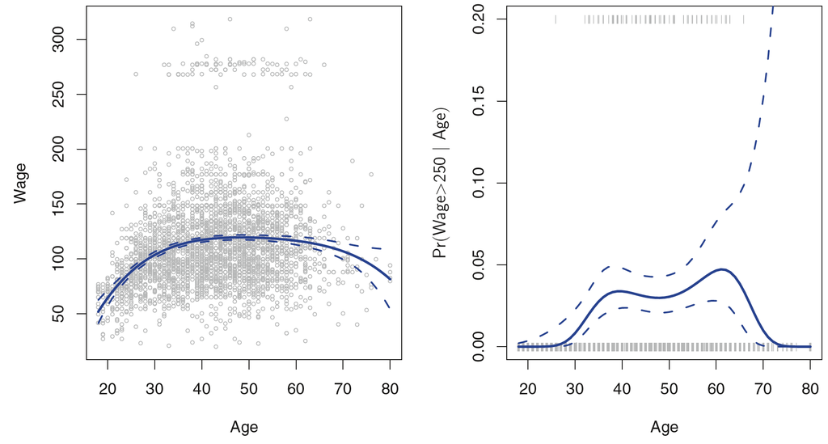

A pair of dotted curves that accompany the fit $2\times$ standard error curves. How do we calculate them? Suppose we have computed the fit at a particular value of age, $x_0$:

$$\hat{f}(x_0) = \hat{\beta}_1 + \hat{\beta}_2 x_0 + \hat{\beta}_3 x_0^2 + \hat{\beta}_4 x_0^3 + \hat{\beta}_5 x_0^4. $$

What is the variance of the fit, i.e. $\text{Var} \big(\hat{f}(x_0)\big)$? Least squares returns variance estimates for each of the fitted coefficients $\hat{\beta}_j$, as well as the covariances between pairs of coefficient estimates (matrix $\hat{\mathbf{C}}$). We can use these to compute the estimated variance of $\hat{f}(x_0)$ by $\ell_0^\top \hat{\mathbf{C}}\ell_0$ where $\ell_0 = (1, x_0, x_0^2, x_0^3, x_0^4)^\top$. The estimated pointwise standard error of $\hat{f}(x_0)$ is the square-root of this variance. This computation is repeated at each reference point $x_0$, and we plot the fitted curve, as well as twice the standard error on either side of the fitted curve.

## Step functions

Using polynomial functions of the features as predictors in a linear model imposes a global structure on the nonlinear function of X.

What can we do if we want to avoid this?

One of the answers is to use step functions instead.

Here we break the range of $X$ into bins, and fit a different constant in each bin. This amounts to converting a continuous variable into an ordered categorical variable.

Specifically, we create cutpoints $c_1, c_2,\ldots, c_K$ in the range of $X$, and then construct $K + 1$ new variables

\begin{align*} C_1(X) &= \mathbb{1}(X<c_1),\\ C_2(X) &= \mathbb{1}(c_1\leq X<c_2),\\ C_3(X) &= \mathbb{1}(c_2\leq X<c_3),\\ &\,\vdots\\ C_{K}(X) &= \mathbb{1}(c_{K-1}\leq X<c_K),\\ C_{K+1}(X) &= \mathbb{1}(c_{K}\leq X). \end{align*}

Notice that for any value of $X$, $C_1(X)+C_2(X)+\ldots+C_{K+1}(X) = 1$, since $X$ must be in exactly one of the $K + 1$ intervals.

We then use least squares to fit a linear model using $C_1(X), C_2(X), \ldots, C_K(X)$ as predictors:

\begin{align*} y_i = \beta_1 + \beta_2 C_2(x_i) + \beta_3 C_3(x_i) +\ldots + \beta_{K+1}C_{K+1}(x_i) + \epsilon_i.\tag{1}\label{eq1} \end{align*}

Note that when $X < c_1$, all of the predictors are zero, so $\beta_1$ can be interpreted as the mean value of $Y$ for $X < c_1$. By comparison, \eqref{eq1} predicts a response of $\beta_1+\beta_j$ for $c_{j-1} \leq X < c_j$, so $\beta_j$ represents the average increase in the response for $X$ in $c_{j-1} \leq X <c_j$ relative to $X <c_1$.

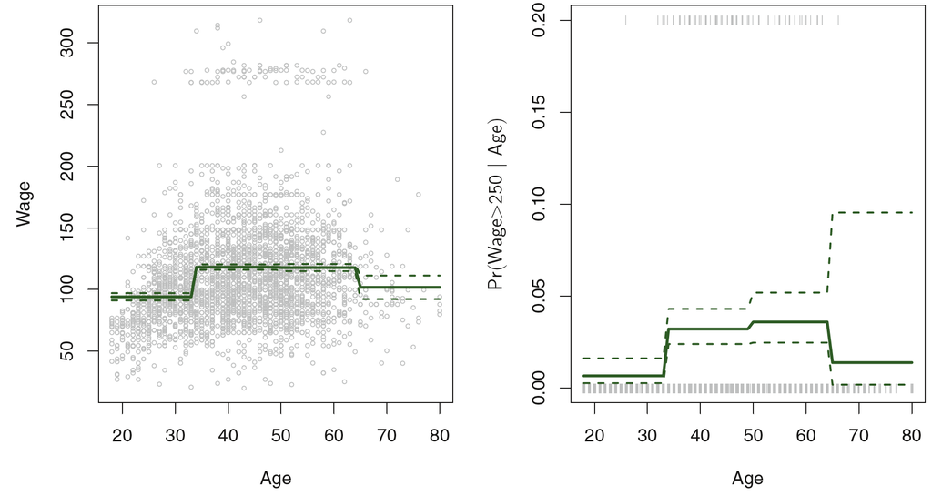

Unfortunately, unless there are natural breakpoints in the predictors, piecewise-constant functions can miss the action. For example, in the lefthand panel above, the first bin clearly misses the increasing trend of wage with age.

Nevertheless, step function approaches are very popular in biostatistics and epidemiology, among other disciplines. For example, $5$-year age groups are often used to define the bins.

## Regression splines

Instead of fitting a high-degree polynomial over the entire range of $X$, piecewise polynomial regression involves fitting separate low-degree polynomials piecewise polynomial regression over different regions of $X$. For example, a piecewise cubic polynomial works by fitting a cubic regression model of the form

\begin{equation} y_{i}=\beta_{1}+\beta_{2} x_{i}+\beta_{3} x_{i}^{2}+\beta_{4} x_{i}^{3}+\epsilon_{i}. \end{equation}

where the coefficients $\beta_1, \beta_2, \beta_3, \beta_4$ differ in different parts of the range of $X$. The points where the coefficients change are called *knots*.

For example, a piecewise cubic with no knots is just a standard cubic polynomial (as in polynomial regression with $d = 3$). A piecewise cubic polynomial with a single knot at a point $c$ takes the form

\begin{equation} y_{i}=\begin{cases} \beta_{11}+\beta_{21} x_{i}+\beta_{31} x_{i}^{2}+\beta_{41} x_{i}^{3}+\epsilon_{i} \quad\text{ if } x_i < c,\\ \beta_{12}+\beta_{22} x_{i}+\beta_{32} x_{i}^{2}+\beta_{42} x_{i}^{3}+\epsilon_{i}\quad \text{ if } x_i \geq c. \end{cases} \end{equation}

In other words, we fit two different polynomial functions to the data, one on the subset of the observations with $x_i < c$, and one on the subset of the observations with $x_i \geq c$. The first polynomial function has coefficients $\beta_{11}, \beta_{21}, \beta_{31}, \beta_{41}$, and the second has coefficients $\beta_{12}, \beta_{22}, \beta_{32}, \beta_{42}$. Each of these polynomial functions can be fit using least squares applied to simple functions of the original predictor.

Using more knots leads to a more flexible piecewise polynomial. In general, if we place $K$ different knots throughout the range of $X$, then we will end up fitting $K + 1$ different cubic polynomials. Note that we do not need to use a cubic polynomial. For example, we can instead fit piecewise linear functions. In fact, our piecewise constant functions from before are piecewise polynomials of degree $0$!

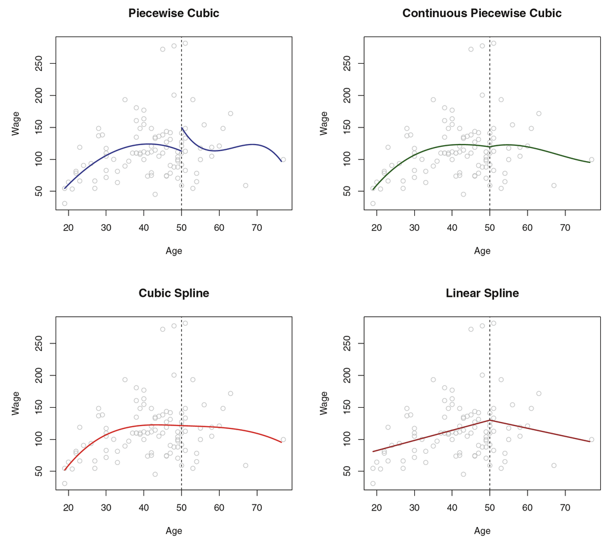

The top left panel above shows a piecewise cubic polynomial fit to a subset of the Wage data, with a single knot at $age=50$. We immediately see a problem: the function is discontinuous! Since each polynomial has four parameters, we are using a total of eight degrees of freedom in fitting this piecewise polynomial model. The fitted curve is just too flexible.

To remedy this problem, we can fit a piecewise polynomial under the constraint that the fitted curve must be continuous. This looks better than the top left plot, but the V-shaped join looks unnatural.

In the lower left plot, we have added two additional constraints: now both the first and second derivatives of the piecewise polynomials are continuous derivative at $age=50$. In other words, we are requiring that the piecewise polynomial be not only continuous when age=50, but also very smooth.

Each constraint that we impose on the piecewise cubic polynomials effectively frees up one degree of freedom, by reducing the complexity of the resulting piecewise polynomial fit. So in the top left plot, we are using eight degrees of freedom, but in the bottom left plot we imposed three constraints (continuity, continuity of the first derivative, and continuity of the second derivative) and so are left with five degrees of freedom.

The curve in the bottom left plot is called a *cubic spline*. In general, a cubic spline with $K$ knots uses cubic spline a total of $4 + K$ degrees of freedom.

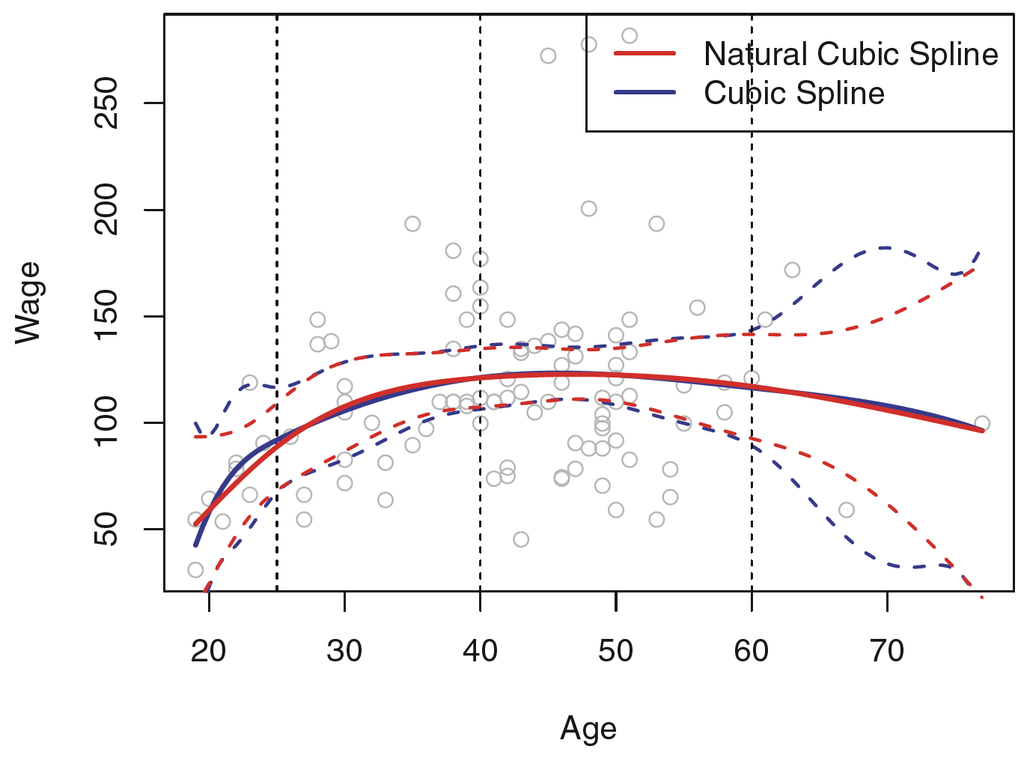

Unfortunately, splines can have high variance at the outer range of the predictors—that is, when $X$ takes on either a very small or very large value. We see that the confidence bands in the boundary region appear fairly wild.

What can we do about that?

A *natural spline* is a regression spline with additional boundary constraints: the natural function is required to be linear at the boundary. This additional constraint means that natural splines generally produce more stable estimates at the boundaries. Note that for the natural spline the corresponding confidence intervals are narrower.

### Where to place the knots?

It is common to place knots in a uniform fashion. One way to do this is to specify the desired degrees of freedom, and then place the corresponding number of knots at uniform quantiles of the data.

How many knots should we use?

One option is to try out different numbers of knots and see which produces the "best looking curve".

A somewhat more objective approach is to use cross-validation. The value of the knots giving the smallest RSS is usually chosen.

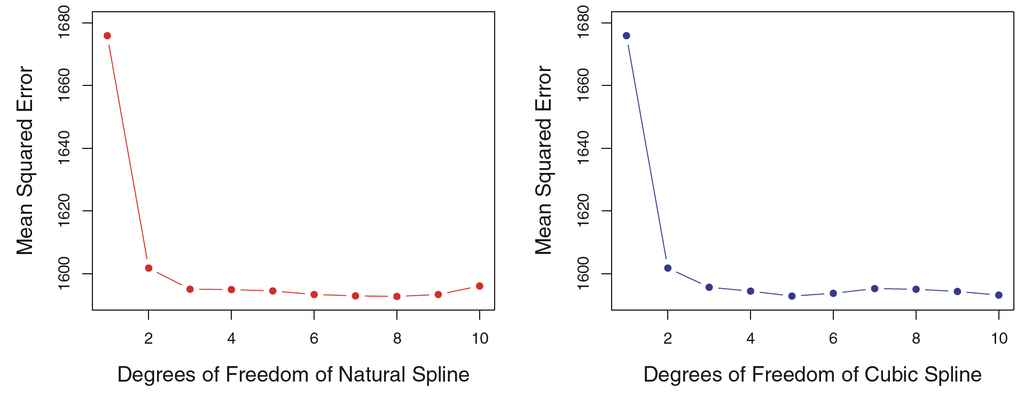

What happens if we fit additive spline models simultaneously on several variables at a time?

This could potentially require the selection of degrees of freedom for each variable. In cases like this we typically adopt a more pragmatic approach and set the degrees of freedom to a fixed number, say four, for all terms.

### Comparison to polynomial regression

1. Splines allow us to place more knots, and hence flexibility, over regions where the function $f$ seems to be changing rapidly, and fewer knots where $f$ appears more stable.
2. The extra flexibility in the polynomial produces undesirable results at the boundaries, while the natural cubic spline still provides a reasonable fit to the data.

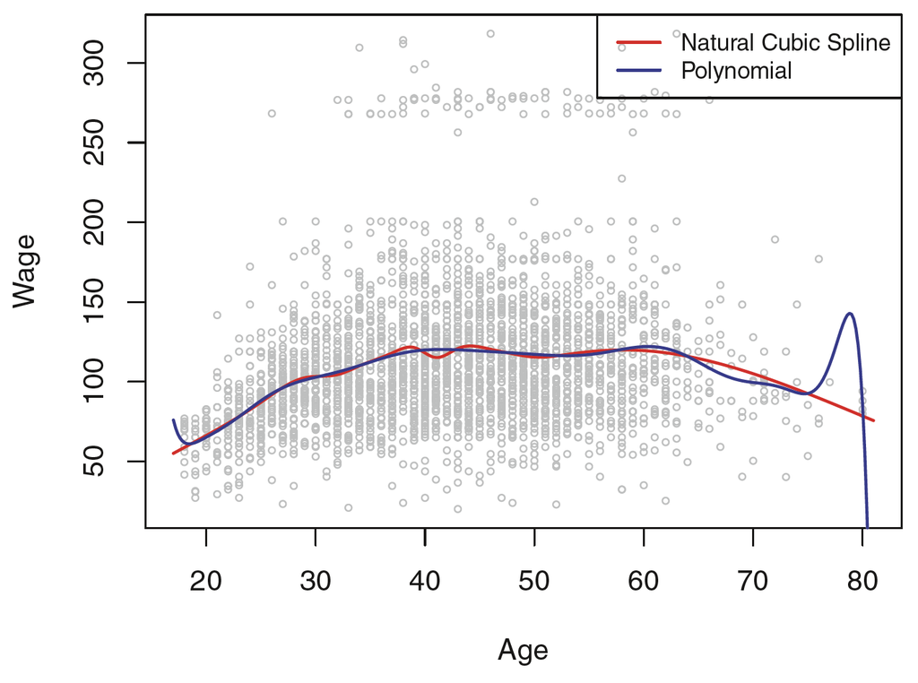

## Kernel methods

Now we look at a different approach for fitting flexible nonlinear functions, which involves computing the fit at a target point $x_0$ using only the nearby training observations. This localization is achieved via a weighting function or *kernel* $K_{h}(x_0, x_i)$, which assigns a weight to $x_i$ based on its distance from $x_0$. Here, $h$ denotes bandwidth, a parameter that dictates the width of the neighborhood.

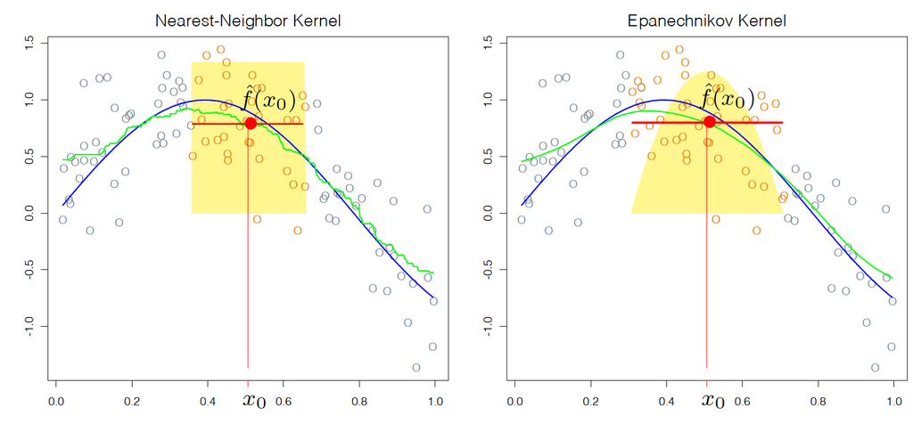

The most common estimator: Nadaraya-Watson kernel averages

$$\hat{f}(x_0) = \frac{\sum_{i=1}^n K_h(x_0 - x_i)y_i}{\sum_{i=1}^n K_h(x_0 - x_i)}$$

where $K_h$ is a kernel with bandwidth $h$, $K_h(x)= K(x/h)$. Typical choice of kernels are:

1. Uniform $$K(u) = \frac{1}{2}\ \mathbf{1}_{(|u|\leq1)}.$$
2. Epanechnikov $$K(u) = \frac{3}{4}(1-u^2)\ \mathbf{1}_{(|u|\leq1)}.$$
3. Gaussian $$K(u) = \frac{1}{\sqrt{2\pi}}e^{-\frac{1}{2}u^2}.$$